# Correction Sujet A – Evaluation 1 – TPSTA401 – 2024

## Exercice 1 (8pts)

Chargement des données avec l’instruction suivante :

```r
diam<-read.table("diamantsPurs.csv",header=T,sep=" ")
```

### question 1 (2pts)

Extraction des échantillons :

```r
x<-diam[diam$cut=="Premium","price"];y<-diam[diam$cut=="VeryGood","price"]
```

### question 2 (3pts)

```r
c(mean(x),sd(x)); c(mean(y),sd(y))
```

```
## [1] 6571.182 2480.586
```

```
## [1] 6612.093 2408.871
```

Les deux échantillons sont respectivement de tailles 44 et 54. Leurs moyennes empiriques sont de 6571 pour les diamants de taille Premium et 6612 pour ceux de taille VeryGood. Leurs écart-types empiriques corrigés (noté $s'$ en cours) sont de 2480 pour les Premium et 2408 pour les VeryGood.

### question 3 (3pts)

Pour comparer ces deux échantillons on peut représenter leurs boxplots sur un même graphique auquel sont ajoutées ici les positions des moyennes (points rouges) :

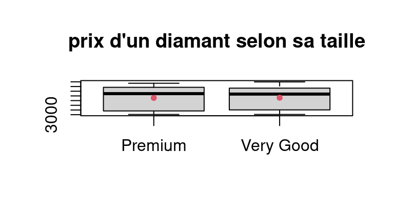

1. Des boxplots qui se ressemblent beaucoup (médianes presque égales et quartiles aussi) signe que la taille n’a pas d’effet sur le prix.
2. Des répartitions dissymétriques avec une étendue de valeurs beaucoup plus importante entre le premier quartile et la médiane qu’entre médiane et second quartile et une moyenne assez différente de la médiane dans chaque échantillon.
3. Des queues de distributions assez similaires et pas d’individus extrêmes

## Exercice 2 (12 pts)

### question 1 (10 pts)

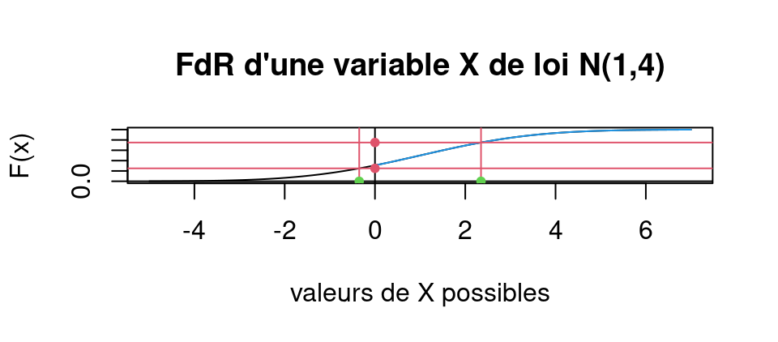

```r
curve(pnorm(x,1,2),xlim=c(-5,7),main="FdR d'une variable X de loi N(1,4)",
      xlab="valeurs de X possibles", ylab="F(x)")# 1 pt pour curve et 0.5 par option : 3 points
curve(pnorm(x,1,2),xlim=c(0,7),col=4,add=T) # 2 points
abline(v=0,h=0) # 1 point (0,5 pour chaque axe)
points(c(0,0),c(0.25,0.75),col=2,pch=20) # 1 point (0,5 pour chaque point)
abline(h=c(0.25,0.75),col=2) # 1 point
abline(v=c(qnorm(0.25,1,2),qnorm(0.75,1,2)),col=2) # 1 point
points(c(qnorm(0.25,1,2),qnorm(0.75,1,2)),c(0,0), col=3, pch=20) # 1 point
```

### question 2 (2 pts)

Dans le graphique suivant représentant la densité d’une variable de loi ${\cal N}(1,4)$ que vaut la surface délimitée par le trait vert (les deux points verts placés sur l’axe des abscisses sont les mêmes que ceux placés sur le précédent graphique) ?

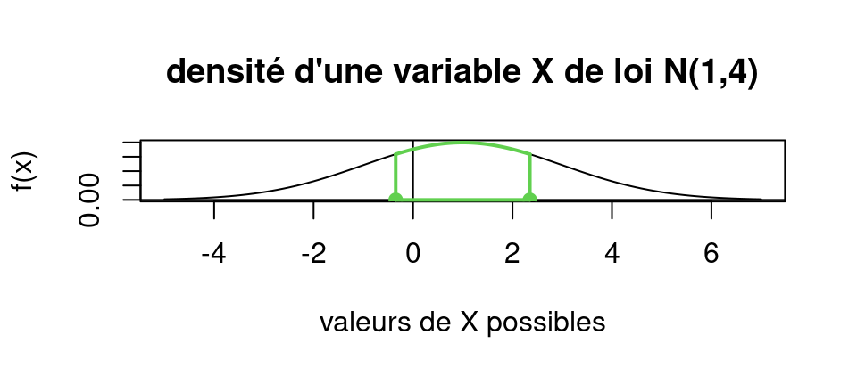

Elle vaut $F(q_{0.75})-F(q_{0.25})=0.75-0.25=0.5$.